# BombusCanadaSpatialAnalysis-Data Preprocess

Data preprocess for Bombus of Canada spatial analysis.

```r
# Load libraries.
library(readr)
library(dplyr)
```

```r
library(ggplot2)
library(spatstat)
library(sp)
library(sf)
library(spatstat.geom)
library(RColorBrewer)
```

## Read dataset

### 1. Read Bombus occurrence data.

```r
# Read occurrence data
bombus_data <- read_tsv("../data/0008996-250402121839773/occurrence.txt")
# Check data.
dim(bombus_data)
```

```
## [1] 16088   223
```

Filter to entries with coordinates and genus `Bombus`:

```r
bombus_filtered <- bombus_data %>%
  filter(!is.na(decimalLatitude), !is.na(decimalLongitude), genus == "Bombus")
```

Removed 282 records without coordinates and not belong to `Bombus`.

Totally, there are 15806 bombus records.

Check `specificEpithet`:

> Definition – Specific Epithet

> In biological taxonomy, a specific epithet is the second part of the scientific name (binomial name) of a species. It identifies the species within a given genus.

```r
unique_specific_epithet_all <- unique(bombus_filtered$specificEpithet)
```

There are 40 specific species in North America.

### 2. Read BC Covariates.

```r
load('../data/BC_Covariates.Rda')

data_covariates <- DATA
```

### 3. Read BC Park

```r
load('../data/BC_Parks.Rda')
data_parks <- DATA

# Create the parks ppp object
ppp_parks <- ppp(
  x = data_parks$Parks$X,
  y = data_parks$Parks$Y,
  window = as.owin(data_parks$Window))

# Add region information as marks
marks(ppp_parks) <- data_parks$Parks$Region
```

## Explore the Covariate Data

```r
sapply(data_covariates, class)
```

```
##            Window         Elevation            Forest               HFI
## "SpatialPolygons"              "im"              "im"              "im"
##        Dist_Water
##              "im"
```

```r
summary(data_covariates)
```

```
##            Length Class           Mode
## Window      1     SpatialPolygons S4
## Elevation  10     im              list
## Forest     10     im              list
## HFI        10     im              list
## Dist_Water 10     im              list
```

### Plot the Window and Image Class Objects

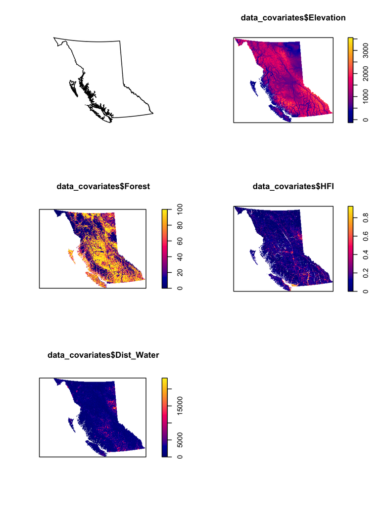

```r
par(mfrow = c(3,2))
plot(data_covariates$Window)
plot(data_covariates$Elevation)
plot(data_covariates$Forest)
plot(data_covariates$HFI)
plot(data_covariates$Dist_Water)
```

## Filter Bumble Bee in BC Province

```r
bombus_bc <- subset(bombus_filtered, stateProvince == "British Columbia")

# View(bombus_bc)
# 3185 223
dim(bombus_bc)
```

```
## [1] 3185  223
```

```r
bumble_bc_percent <- (dim(bombus_bc)[1] / dim(bombus_filtered)[1]) * 100
print(paste(bumble_bc_percent, "% of bumble bee sightings across Canada occurred in BC."))
```

```
## [1] "20.1505757307352 % of bumble bee sightings across Canada occurred in BC."
```

There are **3185** bumble bee occurrences in BC provinces. We removed 12621 records.

### Check `specificEpithet`:

```r
unique_specific_epithet_bc <- unique(bombus_bc$specificEpithet)
```

There are 30 specific species the province of British Columbia, accounting for 75 % of the total found in North America.

### Plot BC province window

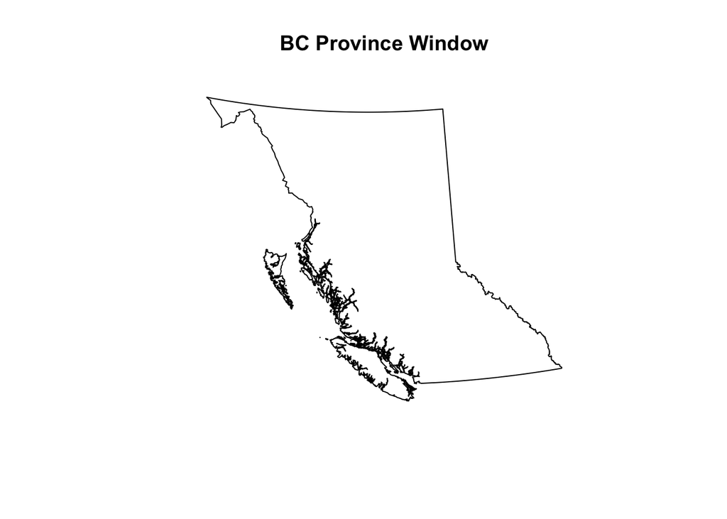

```r
# Convert the window to an owin object
sf_obj <- st_as_sf(data_covariates$Window)
window <- as.owin(sf_obj)
plot(window, main="BC Province Window")
```

### Plot bombus bc dataset

```r
# Check dataset columns.
# colnames(bombus_bc)
```

```r
# Convert the cleaned data frame to an sf object
data_sf <- st_as_sf(bombus_bc, coords = c("decimalLongitude", "decimalLatitude"), crs = 4326)

# Define the target projection
projected_args <- "+proj=aea +lat_0=45 +lon_0=-126 +lat_1=50 +lat_2=58.5 +x_0=1000000 +y_0=0 +datum=NAD83 +units=m +no_defs"

# Transform the coordinates
bombus_bc_projected <- st_transform(data_sf, crs = projected_args)
# View(bombus_bc_projected)
dim(bombus_bc_projected)
```

```
## [1] 3185  222
```

```r
# Get coordinations
bombus_bc_projected_coords <- st_coordinates(bombus_bc_projected)
head(bombus_bc_projected_coords)
```

```
##              X         Y
## [1,] 1467661.3  470452.3
## [2,] 1467661.3  470452.3
## [3,] 1176146.2  399333.2
## [4,]  846420.5 1069165.6
## [5,]  829971.4 1060433.6
## [6,]  846420.5 1069165.6
```

```r
# Convert to ppp object.
ppp_bombus <- ppp(
  x = bombus_bc_projected_coords[, "X"],
  y = bombus_bc_projected_coords[, "Y"],
  window = window)
```

```
## Warning in plot.ppp(ppp_bombus, main = "Bumble Bee in BC Province"): 62 illegal
## points also plotted
```

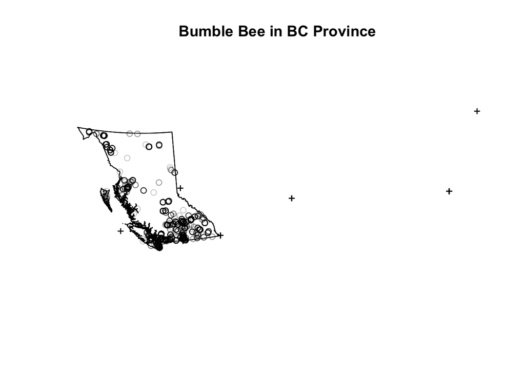

```r
# Plot bombus data
plot(ppp_bombus,  main = 'Bumble Bee in BC Province')
```

### Remove points outside BC province and remove duplicates.

From the above plot warning, we can see there are 62 points outside the BC province window. There are also duplicates in our dataset.

```r
# Filter out points outside the window
inside_window <- bombus_bc_projected_coords[, "X"] >= window$xrange[1] &
                 bombus_bc_projected_coords[, "X"] <= window$xrange[2] &
                 bombus_bc_projected_coords[, "Y"] >= window$yrange[1] &
                 bombus_bc_projected_coords[, "Y"] <= window$yrange[2]

marks_df <- data.frame(
  specificEpithet = bombus_bc_projected$specificEpithet[inside_window],
  locality        = bombus_bc_projected$locality[inside_window]
)

# Convert to ppp object
ppp_bombus <- ppp(x = bombus_bc_projected_coords[inside_window, "X"],
                 y = bombus_bc_projected_coords[inside_window, "Y"],
                 marks  = marks_df,
                 window = window)
```

```
## Warning: 46 points were rejected as lying outside the specified window
```

```
## Warning: data contain duplicated points
```

Remove duplicates.

```r
# Remove duplicates
ppp_bombus <- ppp_bombus[!duplicated(ppp_bombus), ]
```

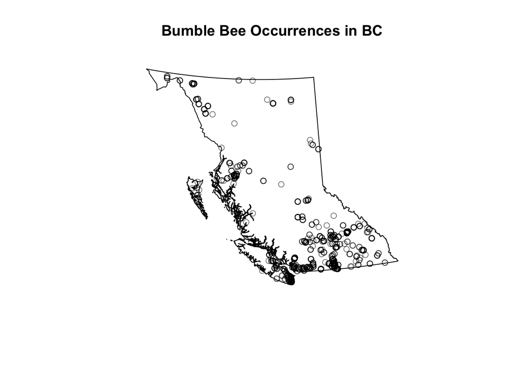

```r
plot(unmark(ppp_bombus), main = "Bumble Bee Occurrences in BC")
```

### Plot Specific Epithet vs. Bumble Bee Occurrences

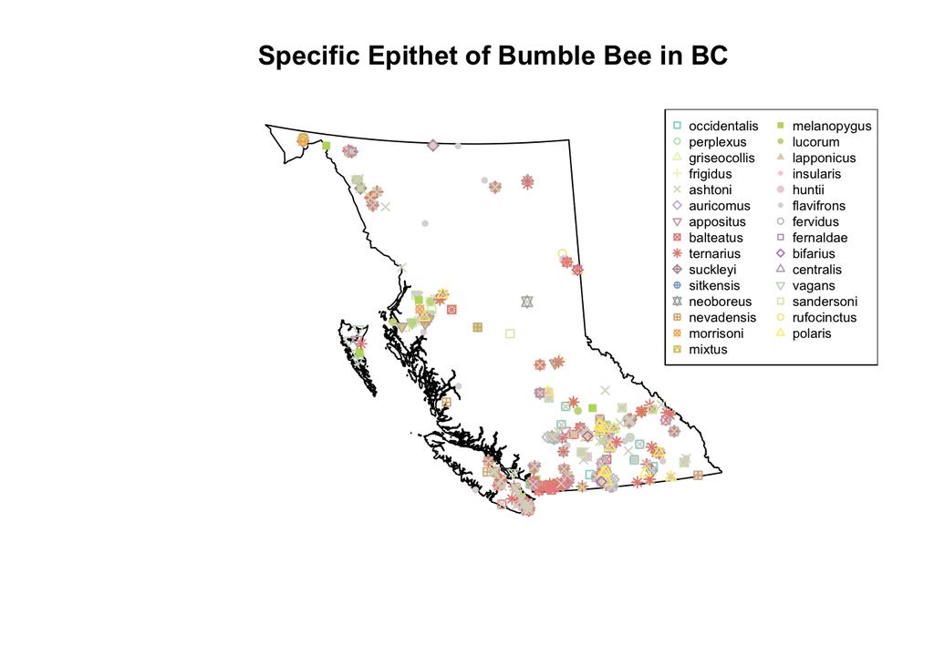

```r
# Extract levels and number of classes
epithet_levels <- unique(marks(ppp_bombus)$specificEpithet)
n_classes <- length(epithet_levels)

# Define color palette
colors <- colorRampPalette(brewer.pal(12, "Set3"))(n_classes)

# Define shape values (repeats if n_classes > 26)
all_shapes <- 0:25
shape_values <- rep(all_shapes, length.out = n_classes)

# Plot
plot(ppp_bombus,
     which.marks = "specificEpithet",
     main        = "Specific Epithet of Bumble Bee in BC",
     cols         = colors,
     pch         = shape_values,
     cex         = 0.8,
     legend      = FALSE
)

# Add a custom legend
legend(
  "topright",
  legend = epithet_levels,
  col    = colors,
  pch    = shape_values,
  cex    = 0.6,
  ncol   = 2
)
```

### Add marks

Add `Distance`, `Dist Water`, `Elevation`, `Forest`, and `HFI` for marks.

```r
length_max <- length(dist)

# Distance -- 984 data points, no missing records.
dist <- nndist(ppp_bombus)

# Dist Water -- 984 data points, no missing records.
dist_water <- data_covariates$Dist_Water[ppp_bombus]

# Elevation -- 982 data points, 2 missing records, replace with NA.
elev <- data_covariates$Elevation[ppp_bombus]
length(elev) <- length_max

# Forest -- 963 data points, 19 missing points, replace with NA.
forest <- data_covariates$Forest[ppp_bombus]
length(forest) <- length_max

# HFI -- 950 data points, 34 missing points, replace with NA.
hfi_bombus <- data_covariates$HFI[ppp_bombus]
length(hfi_bombus) <- length_max

# Add marks.
marks(ppp_bombus)$Dist <- dist
marks(ppp_bombus)$DistWater <- dist_water
marks(ppp_bombus)$Elevation <- elev
marks(ppp_bombus)$Forest <- forest
marks(ppp_bombus)$HFI <- hfi_bombus

head(marks(ppp_bombus))
```

|  | specificEpithet | locality | Dist | DistWater | Elevation | Forest | HFI |
| --- | --- | --- | --- | --- | --- | --- | --- |
| 1 | occidentalis | Similkameen-Okanagan | 777.5459 | 1652.0129 | 841.3041 | 43.2077 | 0.1629217 |
| 3 | occidentalis | Fitzgerald | 0.0000 | 1682.6289 | 841.3041 | 43.2077 | 0.1629217 |
| 4 | perplexus | Kleanza Creek, 14 mi. E Terrace | 0.0000 | 227.0571 | 841.3041 | 43.2077 | 0.1629217 |
| 5 | perplexus | Terrace | 0.0000 | 383.9608 | 841.3041 | 43.2077 | 0.1629217 |
| 6 | perplexus | Kleanza Creek, near Terrace | 0.0000 | 227.0571 | 841.3041 | 43.2077 | 0.1629217 |
| 8 | perplexus | Lake Lisadele, 4000', 58.41, 133.04 | 0.0000 | 843.9896 | 841.3041 | 43.2077 | 0.1629217 |

Plot

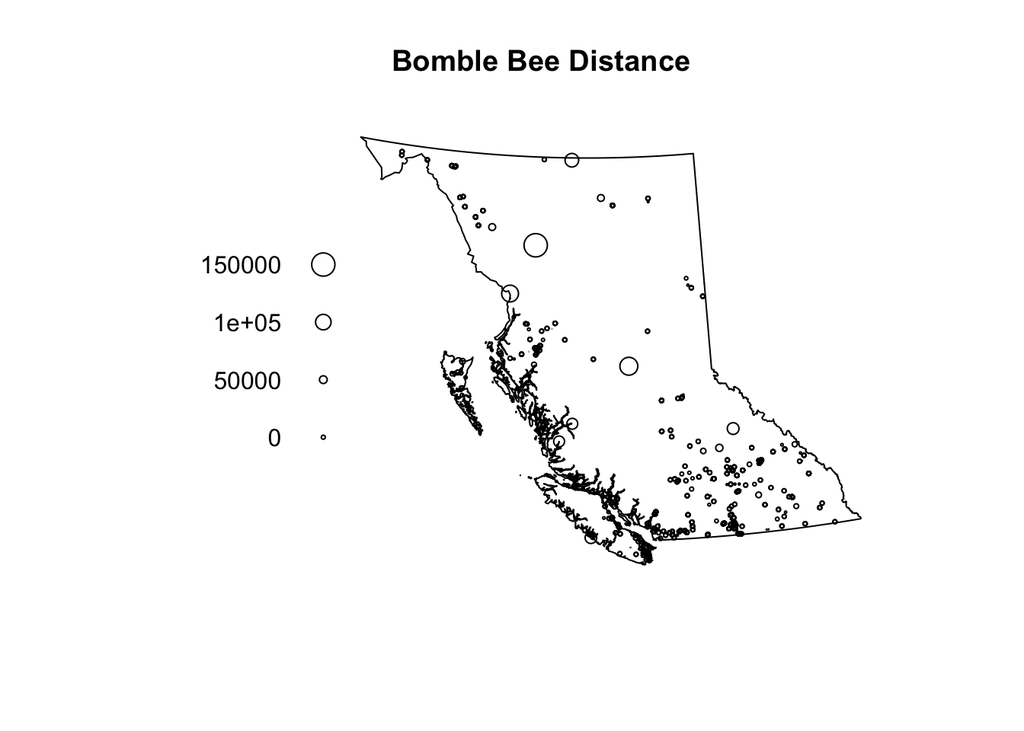

```r
# Plot distance mark.
plot(ppp_bombus, which.marks = "Dist", main = "Bomble Bee Distance")
```

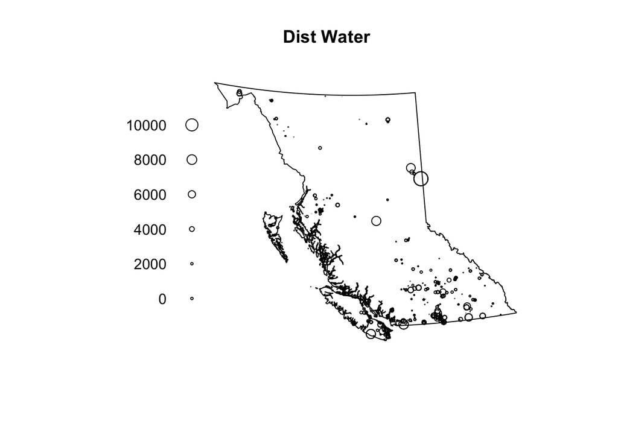

```r
# Plot dist water
plot(ppp_bombus, which.marks = "DistWater", main = "Dist Water")
```

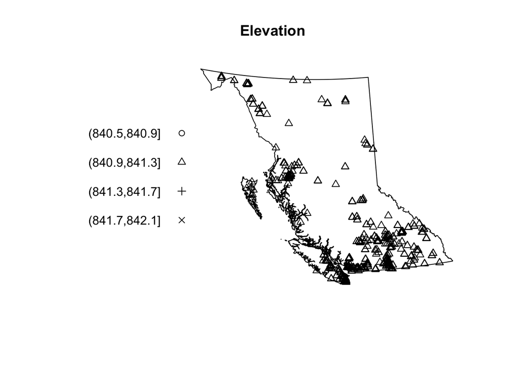

```r
# Plot elevation
ppp_bombus_elev_clean <- subset(ppp_bombus, !is.na(marks(ppp_bombus)$Elevation))
marks(ppp_bombus_elev_clean)$ElevationCut <- cut(marks(ppp_bombus_elev_clean)$Elevation, breaks = 4)
plot(ppp_bombus_elev_clean, which.marks = "ElevationCut", main = "Elevation")
```

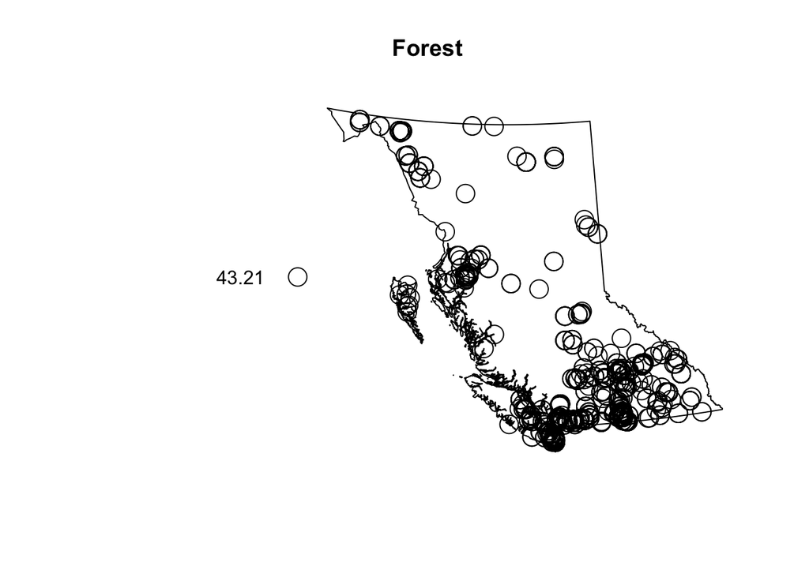

```r
# Plot Forest
ppp_bombus_forest_clean <- subset(ppp_bombus, !is.na(marks(ppp_bombus)$Forest))
plot(ppp_bombus_forest_clean, which.marks = "Forest", main = "Forest")
```

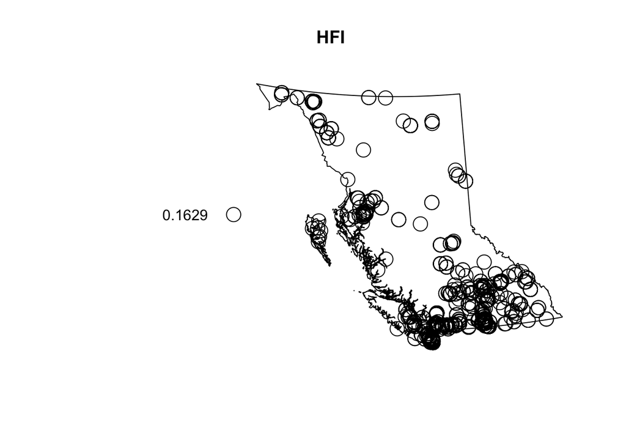

```r
# Plot HFI
ppp_bombus_hfi_clean <- subset(ppp_bombus, !is.na(marks(ppp_bombus)$HFI))
plot(ppp_bombus_hfi_clean, which.marks = "HFI", main = "HFI")
```

## Park

Plot Park vs. Bumble bee occurrences.

```r
# Plot the point pattern & assign to variable for specific information
ppp_parks_plot <- plot(ppp_parks,
                       main = "Parks VS. Bumble Bee Occurrences",
                       col = "grey90",
                       cols = brewer.pal(n = 5, name = "Set2"),
                       pch = c(15, 19, 18, 17, 20),
                       cex = 0.8,
                       legend = FALSE
)

# Add a custom legend with a title 'Region'
legend("topright",
       legend = c("North", "Ok", "South", "Tc", "West", "Bumble Bee"),
       title = "Marks",
       col = c(brewer.pal(n = 5, name = "Set2"), "yellow"),
       pch = c(15, 19, 18, 17, 16, 20),
       cex = 0.8
)

# Plot the bumble bee data points
plot(ppp_bombus, add = TRUE, cols = "black", pch = 20, cex = 0.6)
```

```
## Plotting the first column of marks
```

```
## Plotting the first column of marks
```

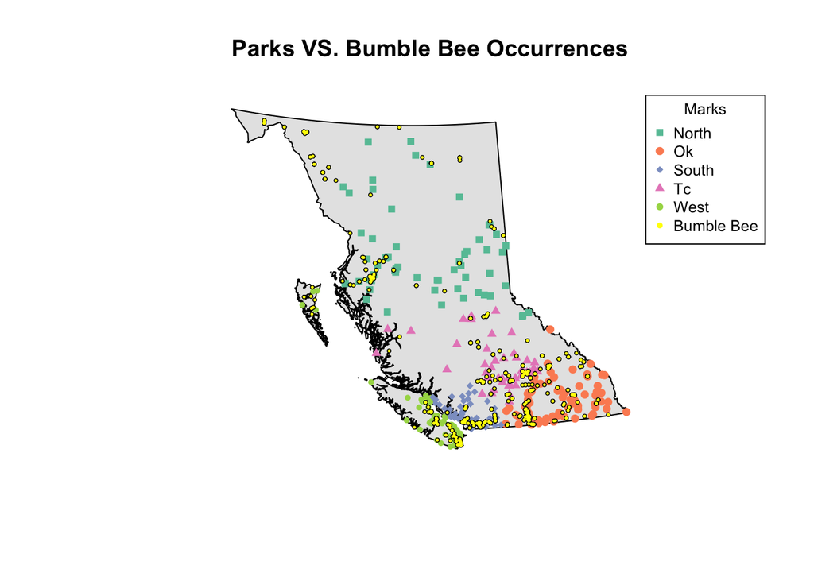

```r
plot(ppp_bombus, add = TRUE, cols = "yellow", pch = 20, cex = 0.3)
```

### Save `ppp_bombus` object

```r
save(ppp_bombus, file = "../data/ppp_bombus.Rda")
```